# Vacunas a nivel comunal en la RM y pobreza multidimensional

Cristóbal Lecaros

2/27/2021

## Intro

**Objetivo**: Revisar el acceso a vacunas para SARS-COV-2 en las diferentes **comunas** de la Región Metropolitana de acuerdo a la **pobreza multidimensional**, la **proporción de adultos mayores de 65 años** y el número de la **población total** viviendo en esas comunas.

## Datos

Para observar las tendencias en el acceso a vacunas a nivel comunal, se utilizaron las siguientes fuentes de datos.

- [Pobreza multidimensional comunal](http://observatorio.ministeriodesarrollosocial.gob.cl/pobreza-comunal-2017): De acuerdo a lo reportado por Ministerio de Desarrollo Social como producto derivado de encuesta CASEN 2017.
- [Vacunación comunal](https://github.com/juancri/covid19-vaccination/blob/master/output/chile-vaccination-comunas.csv): Dato reportado por JC Olivares para el Ministerio de Ciencia.
- Proyección poblacion comunal: Proyecciones de la población censal a nivel comunal para el año 2021, con base en el censo 2017.

## Resultados

### Pobreza Multidimensional por Comunas de la RM

La proporción de pobreza multidimensional en las diferentes comunas, en orden decreciente de arriba a abajo.

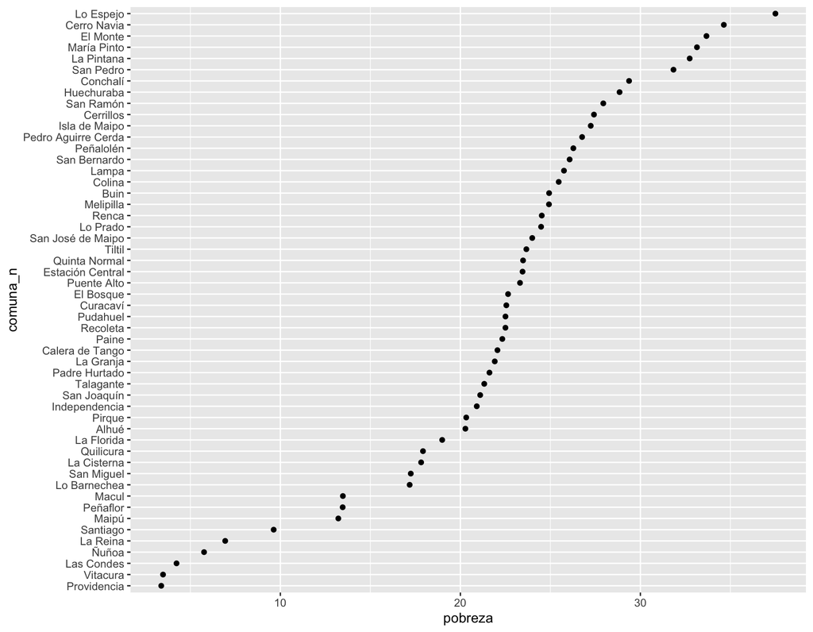

#### Pobreza y Número de Dosis

Se observa una relación entre la proporción de pobreza multidimensional en la comuna y el número de primeras dosis recibidas; las comunas con menos pobreza tienen un número más alto de primera dosis de vacuna.

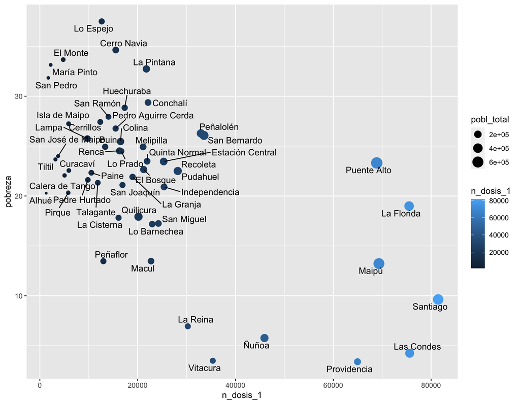

Las 10 comunas que tienen mayor porcentaje de mayores de 65 años son Vitacura, Las Condes, Providencia, San Joaquín, La Reina, San Ramón, Lo Prado, Macul, La Cisterna, Pedro Aguirre Cerda; las que tienen menos son Quilicura, Lampa, Colina, Santiago, Puente Alto, Lo Barnechea, Pudahuel, Buin, San Bernardo, Padre Hurtado. Se observa que la tasa de pobreza multidimensional no guarda relación con el número de adultos mayores de 65 años por comuna.

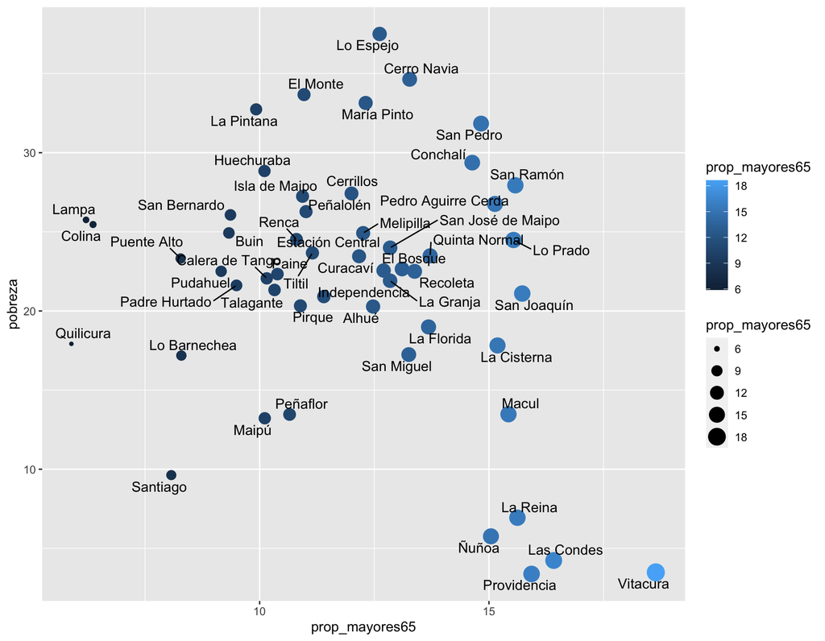

### Tabla y Modelo lineal

| comuna_n | n_dosis_1 | pobreza | prop_mayores65 | pobl_total | razon_dosis_pob65 |
| --- | --- | --- | --- | --- | --- |
| Santiago | 81,443 | 9.6 | 8.1 | 517,280 | 1.95 |
| Cerrillos | 12,358 | 27.4 | 12.0 | 89,520 | 1.15 |
| Cerro Navia | 15,515 | 34.6 | 13.3 | 142,304 | 0.82 |
| Conchalí | 22,122 | 29.4 | 14.6 | 139,394 | 1.08 |
| El Bosque | 21,225 | 22.7 | 13.1 | 171,789 | 0.94 |
| Estación Central | 25,317 | 23.5 | 12.2 | 214,470 | 0.97 |
| Huechuraba | 17,344 | 28.8 | 10.1 | 114,453 | 1.50 |
| Independencia | 25,391 | 20.9 | 11.4 | 147,655 | 1.51 |
| La Cisterna | 16,088 | 17.8 | 15.2 | 101,126 | 1.05 |
| La Florida | 75,502 | 19.0 | 13.7 | 405,185 | 1.36 |
| La Granja | 18,957 | 21.9 | 12.8 | 122,028 | 1.21 |
| La Pintana | 21,776 | 32.7 | 9.9 | 189,454 | 1.16 |
| La Reina | 30,249 | 6.9 | 15.6 | 100,459 | 1.93 |
| Las Condes | 75,610 | 4.2 | 16.4 | 335,296 | 1.37 |
| Lo Barnechea | 22,971 | 17.2 | 8.3 | 126,816 | 2.18 |
| Lo Espejo | 12,645 | 37.5 | 12.6 | 103,381 | 0.97 |
| Lo Prado | 16,655 | 24.5 | 15.5 | 104,405 | 1.03 |
| Macul | 22,727 | 13.5 | 15.4 | 136,278 | 1.08 |
| Maipú | 69,332 | 13.2 | 10.1 | 584,053 | 1.17 |
| Ñuñoa | 45,925 | 5.8 | 15.0 | 255,823 | 1.19 |
| Pedro Aguirre Cerda | 15,490 | 26.8 | 15.1 | 107,409 | 0.95 |
| Peñalolén | 32,929 | 26.3 | 11.0 | 269,296 | 1.11 |
| Providencia | 64,950 | 3.4 | 15.9 | 160,043 | 2.55 |
| Pudahuel | 28,199 | 22.5 | 9.2 | 256,607 | 1.20 |
| Quilicura | 20,164 | 17.9 | 5.9 | 261,993 | 1.31 |
| Quinta Normal | 21,929 | 23.5 | 13.7 | 138,904 | 1.15 |
| Recoleta | 28,115 | 22.5 | 13.4 | 193,605 | 1.09 |
| Renca | 16,285 | 24.5 | 10.8 | 161,959 | 0.93 |
| San Joaquín | 16,894 | 21.1 | 15.7 | 103,871 | 1.03 |
| San Miguel | 24,233 | 17.2 | 13.3 | 136,835 | 1.34 |
| San Ramón | 14,029 | 27.9 | 15.6 | 86,017 | 1.05 |
| Vitacura | 35,354 | 3.5 | 18.6 | 97,695 | 1.94 |
| Puente Alto | 68,884 | 23.3 | 8.3 | 655,033 | 1.27 |
| Pirque | 5,806 | 20.3 | 10.9 | 31,134 | 1.71 |
| San José de Maipo | 3,731 | 24.0 | 12.8 | 18,917 | 1.54 |
| Colina | 16,505 | 25.5 | 6.4 | 185,599 | 1.40 |
| Lampa | 9,727 | 25.8 | 6.2 | 131,436 | 1.19 |
| Tiltil | 3,183 | 23.7 | 11.2 | 21,783 | 1.31 |
| San Bernardo | 33,562 | 26.1 | 9.4 | 339,043 | 1.06 |
| Buin | 13,352 | 24.9 | 9.3 | 111,934 | 1.28 |
| Calera de Tango | 5,049 | 22.1 | 10.2 | 29,019 | 1.71 |
| Paine | 10,526 | 22.3 | 10.4 | 84,379 | 1.20 |
| Melipilla | 21,111 | 24.9 | 12.3 | 143,779 | 1.20 |
| Alhué | 1,293 | 20.3 | 12.5 | 7,536 | 1.38 |
| Curacaví | 5,926 | 22.6 | 12.7 | 36,991 | 1.26 |
| María Pinto | 2,212 | 33.1 | 12.3 | 15,132 | 1.19 |
| San Pedro | 1,727 | 31.8 | 14.8 | 12,132 | 0.96 |
| Talagante | 11,846 | 21.3 | 10.3 | 82,900 | 1.38 |
| El Monte | 4,771 | 33.7 | 11.0 | 40,620 | 1.07 |
| Isla de Maipo | 5,874 | 27.2 | 10.9 | 40,803 | 1.32 |
| Padre Hurtado | 9,817 | 21.6 | 9.5 | 76,219 | 1.36 |
| Peñaflor | 12,987 | 13.5 | 10.7 | 102,667 | 1.19 |

El modelo que que evalúa la relación entre el número de dosis, el porcentaje de pobreza multidimensional, la proporción de adultos $\geq65$ años, y la población total por comuna está definido como:

$$Y(\text{Número de dosis}) \sim \beta_\text{0} + X\beta_\text{pobreza} + X\beta_{\text{}\geq65 \text{años}} + X\beta_\text{población total}.$$

**Tabla. Modelo de regresión lineal**

| **Characteristic** | **Beta** | **95% CI**<sup>1</sup> | **p-value** |
| --- | --- | --- | --- |
| pobreza | -0.21 | -0.31, -0.10 | <0.001 |
| prop_mayores65 | 0.19 | 0.10, 0.28 | <0.001 |
| pobl_total | 0.88 | 0.76, 1.0 | <0.001 |
| pobreza * prop_mayores65 | -0.07 | -0.16, 0.02 | 0.10 |
| pobreza * pobl_total | -0.12 | -0.22, -0.02 | 0.015 |
| prop_mayores65 * pobl_total | 0.12 | 0.01, 0.22 | 0.027 |

<sup>*1*</sup> CI = Confidence Interval

Como es de esperarse, el número de vacunas se correlaciona con el tamaño de la población (a mayor número de gente por comuna más vacunas), con la proporción de adultos mayores de 65 años (entre más adultos $\geq65$ años, más vacunas) y también de manera negativa con la pobreza multidimensional (a mayor pobreza menor número de dosis). Los efectos de interacción entre las variables son pequeños.